# Hmsc - Code for Cindy

Dario Joseph Di Girolamo

2024-12-11

This document will cover how to use Hmsc with the following criteria:  
- Converting species data to presence/absence  
- Merge zooplankton and fish trait data  
- visualize the residual variation as a chord plot

Along with the other code used in the process

I’ll be using the data set from the Arctic watershed as it has the smallest amount of species (n = 81) and lakes (n = 24).

# Data Preperation

I’ll quickly show the packages I’ve used for the data prep

```r
library(readxl)
library(dplyr)
library(tidyr)
library(tibble)
library(missMDA)
library(vegan)
library(openxlsx)
library(mice)
library(VIM)
library(leaflet)
library(sf)
library(ggplot2)
library(cowplot)
library(multcompView)
```

## Environmental Matrix Prep

The first matrix is the environmental variables. The important thing to note with this matrix is that the row names are the lake IDs. This is especially important as we need the same row names in the species matrix.

In this code, I am filtering the dataset for lakes located in the Arctic watershed. I then convert the column of lake IDs into the row names so that these match with the species matrix as I mentioned above.

```r
env.arc <- filter(env.var.red.mice.complete.tran, lake_id %in% spatial.can.arc.list) # 24 lakes
env.arc <- column_to_rownames(env.arc, var = "lake_id")
head(env.arc)
```

```
##             area    depth circularity watershed_area watershed_slope
## 09-370 1.5364239 1.791759   0.6340576      4.7043022       1.3913492
## 09-371 0.3050228 2.001480   0.8836843      1.0953200       1.2782142
## 09-372 0.4117904 2.001480   0.7244577      1.1243414       1.1124997
## 09-373 1.1450034 1.856298   0.5752912      4.1976809       1.5543425
## 09-375 2.5990515 2.890372   0.5076643      5.6640641       0.9810049
## 09-376 0.3690459 2.397895   0.6203410      0.8377698       1.5165729
##        temperature   colour      doc   ph       tp tntp_ratio   sodium
## 09-370        18.9 3.538557 4.141188 8.64 2.934900   2.755758 2.567933
## 09-371        20.6 1.813655 2.416137 8.81 2.691829   3.239830 1.792733
## 09-372        19.1 2.860275 3.281005 8.01 3.000706   3.157222 1.229302
## 09-373        18.8 3.726550 3.287562 8.36 3.550848   2.336079 3.412429
## 09-375        21.1 3.074311 2.211018 9.09 5.788919   1.759065 3.313052
## 09-376        23.0 3.262356 3.629859 9.23 5.835723   2.139197 3.667882
```

## Species Matrix Prep

For the species matrix I filter each individual trophic level to find species located in Arctic lakes and convert the lake ID column into the row names as I did above for the environmental matrix.

```r
phyto.arc <- filter(phyto.troph.wide.clean, lake_id %in% spatial.can.arc.list) #409 sp
phyto.arc.f <- column_to_rownames(phyto.arc, var = "lake_id")

zoo.arc <- filter(zoo.troph.red, lake_id %in% spatial.can.arc.list) #99 sp
zoo.arc.f <- column_to_rownames(zoo.arc, var = "lake_id")

fish.arc <- filter(fish.pa.trophic, lake_id %in% spatial.can.arc.list) #106 sp
fish.arc.f <- column_to_rownames(fish.arc, var = "lake_id")
```

Once this is done for each trophic group I then join all trophic groups into one matrix.

```r
phyto.zoo.arc <- full_join(phyto.arc, zoo.arc, by = "lake_id")

phyto.zoo.fish.arc <- full_join(phyto.zoo.arc, fish.arc, by = "lake_id") #615 sp
phyto.zoo.fish.arc <- column_to_rownames(phyto.zoo.fish.arc, var = "lake_id")
head(phyto.zoo.fish.arc[,c(1:5)])
```

```
##        Cyclotella spp. Lindavia bodanica Achnanthidium minutissimum
## 09-370        0.000000          501.1909                  0.5717698
## 09-371       21.190348            0.0000                  0.0000000
## 09-372        4.784702            0.0000                  0.4764749
## 09-373       31.595070            0.0000                  0.0000000
## 09-375        0.000000            0.0000                  0.0000000
## 09-381       23.696308            0.0000                  0.0000000
##        Navicula spp. Urosolenia longiseta
## 09-370      0.000000                    0
## 09-371     18.250690                    0
## 09-372      5.445427                    0
## 09-373      0.000000                    0
## 09-375      0.000000                    0
## 09-381      0.000000                    0
```

I then filter for species present in a minimum of 4 lakes so as to not include rare species. This might not be necessary for your own work.

We also do it for the individual species matrice as we need to use the filtered species row names later in the trait matrix prep.

```r
phyto.arc.min4 <- phyto.arc.f[colSums(phyto.arc.f==0)<=20] #409 to 51 sp
zoo.arc.min4 <- zoo.arc.f[colSums(zoo.arc.f==0)<=20] #99 to 16 sp
fish.arc.min4 <- fish.arc.f[colSums(fish.arc.f==0)<=20] #106 to 14 sp

phyto.zoo.fish.arc.min4 <- phyto.zoo.fish.arc[colSums(phyto.zoo.fish.arc==0)<=20] #614 to 81 sp
head(phyto.zoo.fish.arc.min4[,c(1:5)])
```

```
##        Cyclotella spp. Lindavia bodanica Achnanthidium minutissimum
## 09-370        0.000000          501.1909                  0.5717698
## 09-371       21.190348            0.0000                  0.0000000
## 09-372        4.784702            0.0000                  0.4764749
## 09-373       31.595070            0.0000                  0.0000000
## 09-375        0.000000            0.0000                  0.0000000
## 09-381       23.696308            0.0000                  0.0000000
##        Navicula spp. Nitzschia spp.
## 09-370      0.000000      0.0000000
## 09-371     18.250690      0.0000000
## 09-372      5.445427      0.6806784
## 09-373      0.000000     27.5674700
## 09-375      0.000000      1.5315260
## 09-381      0.000000      0.0000000
```

The last step is to convert the species matrix to presence/absence

```r
phyto.zoo.fish.arc.min4.pa <- phyto.zoo.fish.arc.min4
phyto.zoo.fish.arc.min4.pa[phyto.zoo.fish.arc.min4.pa > 0] <- 1
head(phyto.zoo.fish.arc.min4.pa[,c(1:5),])
```

```
##        Cyclotella spp. Lindavia bodanica Achnanthidium minutissimum
## 09-370               0                 1                          1
## 09-371               1                 0                          0
## 09-372               1                 0                          1
## 09-373               1                 0                          0
## 09-375               0                 0                          0
## 09-381               1                 0                          0
##        Navicula spp. Nitzschia spp.
## 09-370             0              0
## 09-371             1              0
## 09-372             1              1
## 09-373             0              1
## 09-375             0              1
## 09-381             0              0
```

## Trait Matrix Prep

This part is a little complex and messy but it’ll be worth the trouble as you won’t run into any issues once you run the model.

The trait matrice should be set up with species as the row names, the trait name as the column names and the trait values to fill the matrix.

Here are the steps:  
1. Make a list of species names from the species matrix. Here we use the individual species matrix we filtered above that I mentioned will be used later. This is the later!

```r
phyto.arc.sp.list <- as.list(colnames(phyto.arc.min4))
```

2. Filter the traits matrix by the species list

```r
phyto.trait.length.arc <- filter(phyto.trait.length.merged.sqrt, genus.species %in% phyto.arc.sp.list)
```

3. Find the positions of the species in the trait matrix

```r
phyto.trait.length.arc.positions <- match(phyto.trait.length.arc$genus.species, phyto.arc.sp.list)
```

4. Reorder the species to match the order you pulled from step 3

```r
phyto.trait.length.arc.ro <- phyto.trait.length.arc[order(phyto.trait.length.arc.positions),]
```

5. Convert species into row names for when we run the model. We first have to insert NULL values as row names to avoid errrors

```r
rownames(phyto.trait.length.arc.ro) <- NULL
phyto.trait.length.arc.ro.f <- column_to_rownames(phyto.trait.length.arc.ro, var = "genus.species")
head(phyto.trait.length.arc.ro.f)
```

```
##                                   MLD
## Cyclotella spp.            0.03864906
## Lindavia bodanica          0.04364932
## Achnanthidium minutissimum 0.05488625
## Navicula spp.              0.06155048
## Nitzschia spp.             0.07387489
## Asterionella formosa       0.08797727
```

We then repeat the steps above for the other trophic groups trait matrice

```r
zoo.arc.sp.list <- as.list(colnames(zoo.arc.min4))
zoo.trait.length.arc <- filter(zoo.trait.length.log, Species.name %in% zoo.arc.sp.list)
zoo.trait.length.arc.positions <- match(zoo.trait.length.arc$Species.name, zoo.arc.sp.list)
zoo.trait.length.arc.ro <- zoo.trait.length.arc[order(zoo.trait.length.arc.positions),]
rownames(zoo.trait.length.arc.ro) <- NULL
zoo.trait.length.arc.ro.f <- column_to_rownames(zoo.trait.length.arc.ro, var = "Species.name")

fish.arc.sp.list <- as.list(colnames(fish.arc.min4))
fish.trait.length.arc <- filter(fish.trait.length.log, Species %in% fish.arc.sp.list)
fish.trait.length.arc.positions <- match(fish.trait.length.arc$Species, fish.arc.sp.list)
fish.trait.length.arc.ro <- fish.trait.length.arc[order(fish.trait.length.arc.positions),]
rownames(fish.trait.length.arc.ro) <- NULL
fish.trait.length.arc.ro.f <- column_to_rownames(fish.trait.length.arc.ro, var = "Species")

head(zoo.trait.length.arc.ro.f)
```

```
##                           zoo.length
## Daphnia galeata mendotae -0.06908972
## Daphnia longiremis       -0.35009645
## Daphnia pulicaria         0.17899971
## Acanthocyclops robustus  -0.81492689
## Diacyclops thomasi       -0.40699251
## Mesocyclops edax         -0.55775615
```

```r
head(fish.trait.length.arc.ro.f)
```

```
##                        fish.length
## Catostomus catostomus     4.158883
## Catostomus commersonii    4.174387
## Coregonus clupeaformis    4.605170
## Culaea inconstans         2.163323
## Esox lucius               5.010635
## Lota lota                 5.023881
```

The last step is to then merge the individual trait matrice into one. We first create a list a row names from the individual matrice, merge the tables, and make the list of row names from earlier the new row names.

I have found the easiest way to merge the tables is to first create empty columns with the same trait names, and then merge the individual trait matrice into the merged matrix, which will be done by the column name. Because of this, you have to ensure that the column name you use is the same as the column name in the individual trait matrice

```r
merged.trait.arc.row <- c(row.names(phyto.trait.length.arc.ro.f),
                          row.names(zoo.trait.length.arc.ro.f),
                          row.names(fish.trait.length.arc.ro.f))

phyto.trait.arc <- phyto.trait.length.arc.ro.f
phyto.trait.arc$zoo.length <- NA
phyto.trait.arc$fish.length <- NA

phyto.zoo.trait.arc <- full_join(phyto.trait.arc, zoo.trait.length.arc.ro.f)
phyto.zoo.fish.trait.arc <- full_join(phyto.zoo.trait.arc, fish.trait.length.arc.ro.f)

row.names(phyto.zoo.fish.trait.arc) <- merged.trait.arc.row

head(phyto.zoo.fish.trait.arc)
```

```
##                                   MLD zoo.length fish.length
## Cyclotella spp.            0.03864906         NA          NA
## Lindavia bodanica          0.04364932         NA          NA
## Achnanthidium minutissimum 0.05488625         NA          NA
## Navicula spp.              0.06155048         NA          NA
## Nitzschia spp.             0.07387489         NA          NA
## Asterionella formosa       0.08797727         NA          NA
```

You’ll notice that there are NA values in this table. This is fine for now as we will deal with it once we run the model.

## Data Preparation Final Items

These are the final items that we will now use in the next section for running the model.

```r
# Spatial data
spatial.can.arc.f

# environmental variable
env.arc

# Phytoplankton + Zooplankton + Fish P/A
phyto.zoo.fish.arc.min4.pa

# Phytoplankton + Zooplankton + Fish Trait
phyto.zoo.fish.trait.arc
```

# Running the Model

The next bit of code is from Run 287. It is worth mentioning as you’ll see the number sprinkled throughout the code. This is because I created a default script for my model runs with a place holder of ‘?0’ (as no code uses this) in the script which I replaced using ‘ctrl + f’ with the number of the run. It would take too long to remove the number from the code so hopefully its not too much of an issue.

Here are the packages used in the script. There is also a later section of packages used for the visualization.

```r
library(Hmsc)
library(pryr)
library(beepr)
library(knitr)
library(ggplot2)
```

## Load in the data

```r
#environmental data
run.287.env <- env.arc

#spatial data
run.287.spatial <- spatial.can.arc.f

#trophic data
run.287.trophic <- phyto.zoo.fish.arc.min4.pa

#trait data
run.287.trait <- phyto.zoo.fish.trait.arc
```

## Prepare the trait matrix for the model - Tr Matrix

To prepare the trait data, it is as simple as replacing the NA values with 0. I then call on the column names of the traits for the model structure below.

```r
run.287.trait.prep <- run.287.trait
run.287.trait.prep[is.na(run.287.trait.prep)] <- 0
colnames(run.287.trait.prep)
```

```
## [1] "MLD"         "zoo.length"  "fish.length"
```

## Set Model Fitting Parameters

These values might vary based on your own work, but these values are the ones that I found to work best in my own models.

```r
#how many chains to sample
nChains = 2
#how many samples to obtain per chain
samples = 1000
#how much thinning to apply
thin = 5
#length of the transient
transient = 500*thin
#verbose
verbose = 500*thin
```

## Define the spatial random effect

Here we set up the spatial random effect that will be included in the model

```r
# To define a spatial random effect at the level of the sampling site, we need
#to include the site id in the studyDesign
studyDesign.287 <- rownames(run.287.spatial)
studyDesign.287 = data.frame(SiteID = as.factor(studyDesign.287))
rL.287 = HmscRandomLevel(units = studyDesign.287$SiteID)
```

## Model Structure

Here we set up the model structure.

A few things to make note of:  
- TrFormula you write the column names from the trait matrix that we pulled above  
- StudyDesign and ranLevels takes the spatial set up we ran just above  
- for distr, make sure that you are running ‘probit’ as you are now using presence/absence data

```r
r287.model <- Hmsc(Y = run.287.trophic,
                   XData = run.287.env,
                   TrData = run.287.trait.prep,
                   TrFormula = ~ MLD + zoo.length + fish.length,
                   studyDesign = studyDesign.287,
                   ranLevels = list("SiteID" = rL.287),
                   distr= ("probit"),YScale = TRUE, XScale = TRUE)
```

### Running the Model

Here is a fun bit of code that I have written that will give you the time taken to run the model, the memory used, and it will also beep once the code is done.

I extracted the time and memory taken in the case that I needed to use an online resource to run my models.

The beepr function is a fun package that beeps once the code is done running. With the sound argument you can select a different noise. I have selected the noise from the older Mario video games when you complete a level!

[figure not shown]

```r
{start.time <- Sys.time()
start.memory <- mem_used()
r287.model = sampleMcmc(r287.model, thin = thin, samples = samples,
                        transient = transient, nChains = nChains,
                        verbose = verbose)
print(Sys.time() - start.time)
print(mem_used() - start.memory)
beep(sound = 8)}
```

```
## Computing chain 1
## Chain 1, iteration 2500 of 7500 (transient)
## Chain 1, iteration 5000 of 7500 (sampling)
## Chain 1, iteration 7500 of 7500 (sampling)
## Computing chain 2
## Chain 2, iteration 2500 of 7500 (transient)
## Chain 2, iteration 5000 of 7500 (sampling)
## Chain 2, iteration 7500 of 7500 (sampling)
## Time difference of 1.855097 mins
## 44.7 MB
```

I would now highly recommend saving your workspace here so that the next section of code where we visualize can be done without having to run the model once again.

### Examining Model Fit and Parameters

To make sure the model is properly fit we look at the MCMC convergence and want to see a number close to 1, the closer the better.

```r
mpost.287 = convertToCodaObject(r287.model)
mean(gelman.diag(mpost.287$Beta,multivariate=FALSE)$psrf[,1])
```

```
## [1] 1.001632
```

```r
mpost.287 = convertToCodaObject(r287.model)
plot(mpost.287$Beta)
```

[output not shown]

### Explanatory Power of the Model

Here we can now pull the model TjurR2 (probit version of R2) to check the explanatory power of the model

```r
preds.287 = computePredictedValues(r287.model)
MF.287 = evaluateModelFit(r287.model, predY = preds.287)
mean(MF.287$TjurR2)
```

```
## [1] 0.2662734
```

# Default figures

We’ll now go over the default figures that can be made in hmsc. Below I will cover my own adjusted figures that might be more useful depending on your own needs.

These figures can be quite finnicky which is why you’ll often see different paramter margins used for the different figures. With this in mind, don’t forget to use the function dev.off() before moving on to the next figure

## Species Niches - Beta

Here we plot the betas. I have commented on how the different numbers in the code affect the plot.

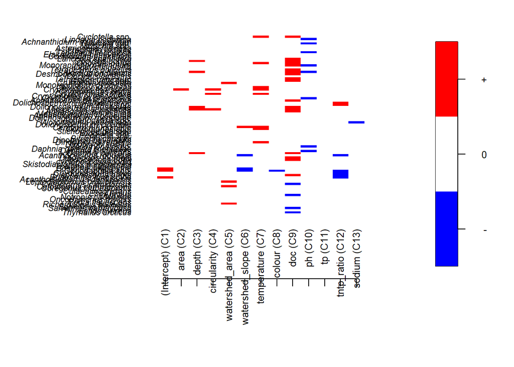

```r
postBeta.287 = getPostEstimate(r287.model, parName = "Beta")
par(mar = c (10,10,2,2))
plotBeta(r287.model, post = postBeta.287, param = "Sign", plotTree = FALSE,
         supportLevel = 0.95, mar = NULL, spNamesNumbers = c(T,F),
         cex = c(0.8,0.7,0.8))
```

```r
#param - controls which parameter is plotted. Sign indicates whether the
#response is positive, negative, or neither given the chosen support level
#plotTree - true if phylogeny is plotted
#supportLevel - controls threshold posterior support for plotting
#cex - covariate name, species name, color legend axis labels
```

## Trait influence on Species Niche - Gamma

Here we plot the Gammas.

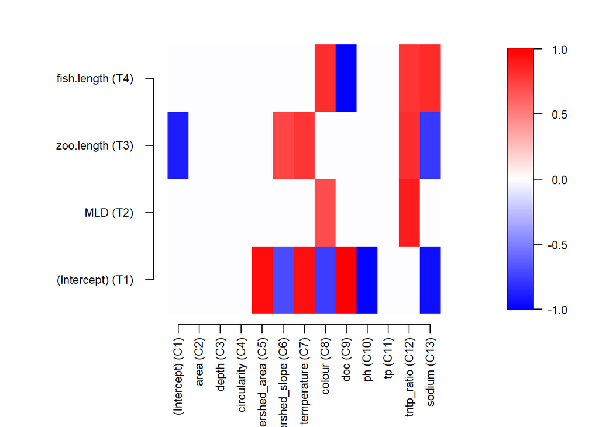

```r
postGamma.287 = getPostEstimate(r287.model, parName = "Gamma")
par(mar = c(12,12,1,2))
plotGamma(r287.model, post = postGamma.287,
          #param = "Sign",
          supportLevel = 0.85)
```

## Variance Parition

Ensure that the column names match the group names, and that the number of groups is the same number we see in ‘group.287’.

I have written my own plot function for the variance partition that I can share with you if need be. This function gives more control for adjusting the plot as needed.

Make sure that the number of colours listed in the plot is the same as the groups identified in group.287

```r
colnames(r287.model$X)
```

```
##  [1] "(Intercept)"     "area"            "depth"           "circularity"
##  [5] "watershed_area"  "watershed_slope" "temperature"     "colour"
##  [9] "doc"             "ph"              "tp"              "tntp_ratio"
## [13] "sodium"
```

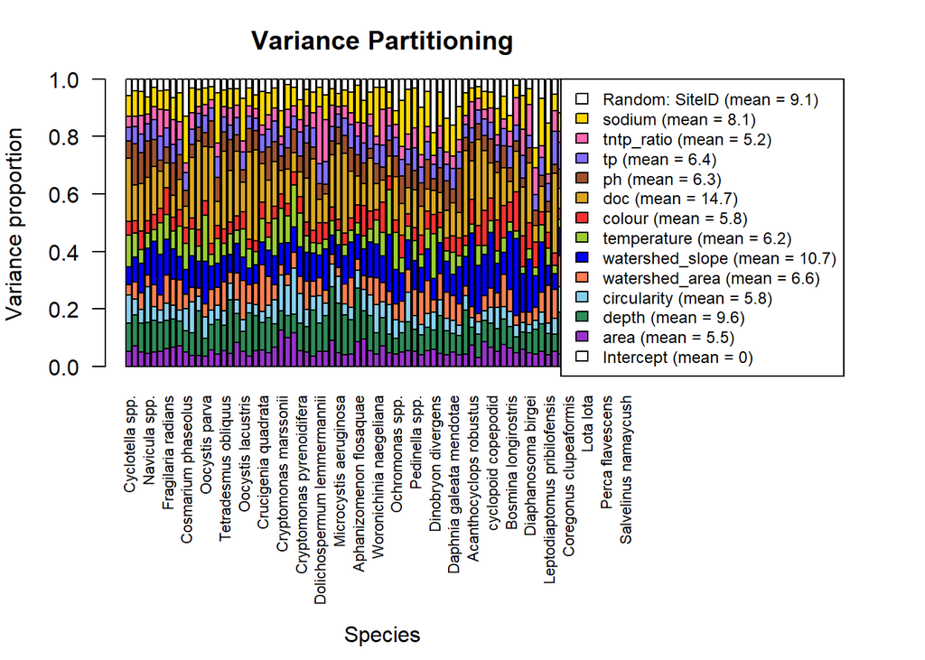

```r
groupnames.287 = c("Intercept",
                   "area",
                   "depth",
                   "circularity",
                   "watershed_area",
                   "watershed_slope",
                   "temperature",
                   "colour",
                   "doc",
                   "ph",
                   "tp",
                   "tntp_ratio",
                   "sodium")
group.287 = c(1,2,3,4,5,6,7,8,9,10,11,12,13)
VP.287 = computeVariancePartitioning(r287.model, group = group.287, groupnames=groupnames.287)

par(mar=c(11,4,3,10))
#first controls the bottom marging, second the left, third the top and forth the right
par(mgp = c(3,1,0))
#first controls the distance of the axis label from the ais line
#second controls the distane of the axis label from the rick labels
#third controls the distance of the tick labels from the axis line

source("plotVariancePartitioning.1.R")
#source adjusted function for making plots

#non spatial effect

plotVariancePartitioning.1(r287.model,VP.287, las=2,
                           cex.names = 0.7,
                           args.legend = list(x = "topright", inset = c(-0.33,0),
                                              cex = 0.75),
                           cols=c("white","darkorchid","seagreen","skyblue","coral","blue","olivedrab3",
                                  "firebrick1","goldenrod","sienna",
                                  "slateblue1","hotpink","gold"))
mtext("Species", side = 1, line = 9.5)
```

## Additional stats

Here we can pull the values from the Variance Partition plot which we will need to do later on for my adjusted figures.

```r
VP.287$vals[,c(1:5)]
```

```
##                 Cyclotella spp. Lindavia bodanica Achnanthidium minutissimum
## Intercept            0.00000000        0.00000000                 0.00000000
## area                 0.05306595        0.07237264                 0.04903281
## depth                0.09650124        0.10579355                 0.10193300
## circularity          0.10001732        0.05646288                 0.04705631
## watershed_area       0.03422167        0.05874395                 0.05719202
## watershed_slope      0.06169078        0.08628678                 0.10344343
## temperature          0.11174621        0.08388916                 0.04872830
## colour               0.04693030        0.04273420                 0.06328257
## doc                  0.21943215        0.12526045                 0.16565733
## ph                   0.06142811        0.14272578                 0.10624278
## tp                   0.04665472        0.05940194                 0.06494297
## tntp_ratio           0.03857408        0.03685474                 0.06446894
## sodium               0.07167069        0.08775118                 0.08494961
## Random: SiteID       0.05806678        0.04172275                 0.04306993
##                 Navicula spp. Nitzschia spp.
## Intercept          0.00000000     0.00000000
## area               0.04435911     0.04973208
## depth              0.10765245     0.11123754
## circularity        0.12570172     0.04651704
## watershed_area     0.03990209     0.07701663
## watershed_slope    0.09248518     0.15130537
## temperature        0.05292763     0.03990026
## colour             0.04467565     0.05310273
## doc                0.14980231     0.16609547
## ph                 0.12583099     0.09286192
## tp                 0.06160778     0.07157461
## tntp_ratio         0.03294190     0.04534564
## sodium             0.05979200     0.06530594
## Random: SiteID     0.06232119     0.03000479
```

We can also see the R2 for the individual environmental variables within the model

```r
kable(VP.287$R2T$Beta)
```

|  | x |
| --- | --- |
| (Intercept) | 0.3866164 |
| area | 0.2810133 |
| depth | 0.1225215 |
| circularity | 0.2330469 |
| watershed_area | 0.1704163 |
| watershed_slope | 0.2244363 |
| temperature | 0.1406764 |
| colour | 0.3992600 |
| doc | 0.4460377 |
| ph | 0.1187796 |
| tp | 0.2948875 |
| tntp_ratio | 0.3895703 |
| sodium | 0.2772191 |

As well as see the R2 explained by traits - gamma. I do understand that in the code you can see a ‘Y’ but this is not in reference to any matrice, but rather the closest english letter to the greek letter for gamma.

```r
VP.287$R2T$Y
```

```
## [1] 0.1561553
```

## Spatial Variation

Here we can check if any variation in the model is explained by spatial autocorrelation

```r
round(summary(mpost.287$Alpha[[1]], quantiles
              = c(0.025,0.5,0.975))[[2]],2)
```

```
##                 2.5% 50% 97.5%
## Alpha1[factor1]    0   0     0
## Alpha1[factor2]    0   0     0
## Alpha1[factor3]    0   0     0
## Alpha1[factor4]    0   0     0
## Alpha1[factor5]    0   0     0
```

# Adjusted Figures

Here are the packages used for these figures

```r
library(ggplot2)
library(cowplot)
library(corrplot)
library(reshape2)
library(ggbreak)
library(dplyr)
library(tibble)
library(circlize)
```

## Residual Variation - Omega

I’ll first go over the default residual diagrams and will include a chord diagram section below.

We first start by extracting the residuals (Omega) from the model. This does require quite a bit of power so this is where I’d recommend saving your second version of the workspace. This way if you return to fix figures you don’t have to rerun the model and the output parameters.

```r
OmegaCor.287 = computeAssociations(r287.model)
```

Save workspace version 2

Set the support level here. I’d recomend starting at 0.95 and either increasing or decreasing as best fits your needs. I’ve set it to 0.85 here so that you can see the figures as there aren’t many residuals in this model.

```r
supportLevel = 0.85
```

We next set the sequence of each species manually. This will make things easier in the next steps.

In your case Cindy you’ll just have 2 trophic groups so it’ll be a minor adjustment

```r
total.seq <- 1:81
phyto.seq <- 1:51
zoo.seq <- 52:67
fish.seq <- 68:81
```

The next bit of code is for assigning the trophic group colours that will be used later in the chord diagrams

```r
group.membership <- c(total.seq)
group.membership[phyto.seq] <- 1
group.membership[zoo.seq] <- 2
group.membership[fish.seq] <- 3

group.colours <- c("forestgreen", "blue", "darkorchid")

group.colours.vector <- group.colours[group.membership]
```

Here we pull the data from the default omega output from the model

```r
toPlot = ((OmegaCor.287[[1]]$support>supportLevel)
          + (OmegaCor.287[[1]]$support<(1-supportLevel))>0)*OmegaCor.287[[1]]$mean
```

I then filtered the omega data to only include significant associations between species. This will make the figure smaller, and allow easier reading of species names.

```r
toPlot.cut <- toPlot
toPlot.cut.filt <- toPlot.cut[rowSums(toPlot.cut != 0) > 1, colSums(toPlot.cut != 0) > 1]
```

This residuals can now be plotted. I would suggest sorting by AOE as this groups the associations in the figure in a much nicer way.

```r
plotOrder = corrMatOrder(OmegaCor.287[[1]]$mean,order="AOE")

group.membership.ordered <- group.membership[plotOrder]
group.colours.vector.aoe <- group.colours[group.membership.ordered]
```

Here is the full residuals with species coloured by trophic group.

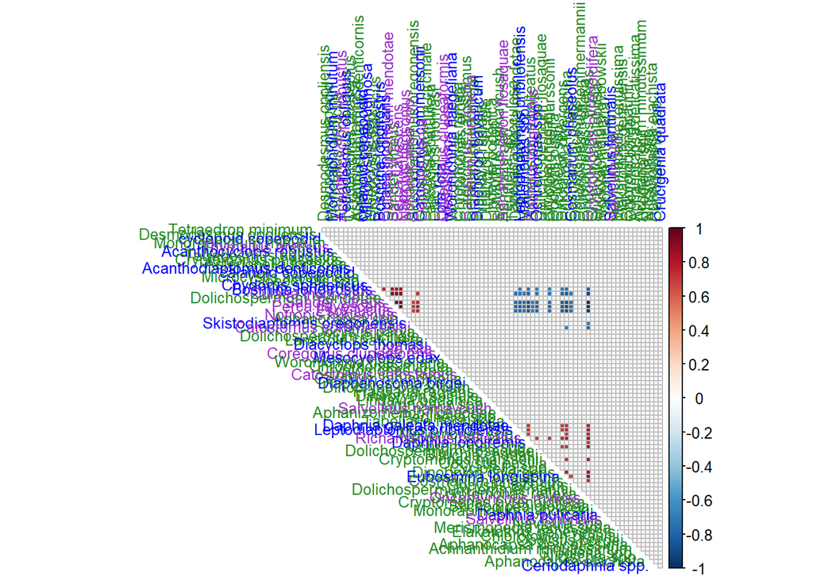

```r
corrplot(toPlot[plotOrder,plotOrder],
         method = "color", type = "upper", tl.cex=0.8,
         col = rev(COL2("RdBu", 200)),
         tl.col = group.colours.vector.aoe,
         addgrid.col = "grey",
         diag = FALSE)
```

This figure shows only the significant associations, but I haven’t figured out how to colour the species by trophic group as you see above.

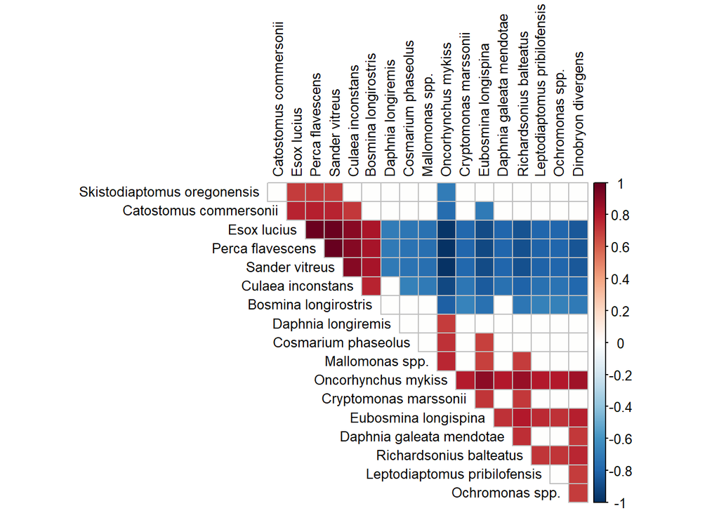

```r
corrplot(toPlot.cut.filt, order = "AOE",
         method = "color", type = "upper", tl.cex=0.8,
         col = rev(COL2("RdBu", 200)),
         tl.col = "black",
         addgrid.col = "grey",
         diag = FALSE)
```

We can now pull just associations between phytoplankton and zooplankton, and zooplankton and fish, convert it to long format, and remove 0 correlation values (no correlation), ad 1 correlation values (the diagonal - species interacting with themselves will always = 1).

```r
# associations between phytoplankton and zooplankton
toPlot.pz <- toPlot[phyto.seq, zoo.seq]
toPlot.pz.long <- melt(toPlot.pz)
colnames(toPlot.pz.long) <- c("To", "From", "Correlation")
toPlot.pz.long <- toPlot.pz.long[toPlot.pz.long$Correlation !=1,]
toPlot.pz.long <- toPlot.pz.long[toPlot.pz.long$Correlation !=0,]

# associations between zooplankton and fish
toPlot.zf <- toPlot[zoo.seq, fish.seq]
toPlot.zf.long <- melt(toPlot.zf)
colnames(toPlot.zf.long) <- c("To", "From", "Correlation")
toPlot.zf.long <- toPlot.zf.long[toPlot.zf.long$Correlation !=1,]
toPlot.zf.long <- toPlot.zf.long[toPlot.zf.long$Correlation !=0,]
```

The number of associations can be represented in a table if needed in either number form

```r
omega.matrix.287 <- ((OmegaCor.287[[1]]$support>supportLevel)
                     + (OmegaCor.287[[1]]$support<(1-supportLevel))>0)*OmegaCor.287[[1]]$mean

omega.dataframe.287 <- data.frame(omega.matrix.287)

omega.sp.summary.287 <- matrix(nrow = 6, ncol = 3)
colnames(omega.sp.summary.287) <- c("Associations", "Positive", "Negative")

{
  omega.dataframe.287.phyto <- omega.dataframe.287[1:51, 1:51]
  omega.sp.summary.287[1,1] <- "Phyto-Phyto"
  omega.sp.summary.287[1,2] <- (sum(colSums(omega.dataframe.287.phyto > 0 & omega.dataframe.287.phyto < 1)))/2
  omega.sp.summary.287[1,3] <- (sum(colSums(omega.dataframe.287.phyto > -1 & omega.dataframe.287.phyto < 0)))/2

  omega.dataframe.287.zoo <- omega.dataframe.287[52:67, 52:67]
  omega.sp.summary.287[2,1] <- "Zoo-Zoo"
  omega.sp.summary.287[2,2] <- (sum(colSums(omega.dataframe.287.zoo > 0 & omega.dataframe.287.zoo < 1)))/2
  omega.sp.summary.287[2,3] <- (sum(colSums(omega.dataframe.287.zoo > -1 & omega.dataframe.287.zoo < 0)))/2

  omega.dataframe.287.fish <- omega.dataframe.287[68:81, 68:81]
  omega.sp.summary.287[3,1] <- "Fish-Fish"
  omega.sp.summary.287[3,2] <- (sum(colSums(omega.dataframe.287.fish > 0 & omega.dataframe.287.fish < 1)))/2
  omega.sp.summary.287[3,3] <- (sum(colSums(omega.dataframe.287.fish > -1 & omega.dataframe.287.fish < 0)))/2


  omega.dataframe.287.zoo.phyto <- omega.dataframe.287[1:51, 52:67]
  omega.sp.summary.287[4,1] <- "Phyto-Zoo"
  omega.sp.summary.287[4,2] <- sum(colSums(omega.dataframe.287.zoo.phyto > 0 & omega.dataframe.287.zoo.phyto < 1))
  omega.sp.summary.287[4,3] <- sum(colSums(omega.dataframe.287.zoo.phyto > -1 & omega.dataframe.287.zoo.phyto < 0))


  omega.dataframe.287.zoo.fish <- omega.dataframe.287[52:67, 68:81]
  omega.sp.summary.287[5,1] <- "Zoo-Fish"
  omega.sp.summary.287[5,2] <- sum(colSums(omega.dataframe.287.zoo.fish > 0 & omega.dataframe.287.zoo.fish < 1))
  omega.sp.summary.287[5,3] <- sum(colSums(omega.dataframe.287.zoo.fish > -1 & omega.dataframe.287.zoo.fish < 0))


  omega.dataframe.287.phyto.fish <- omega.dataframe.287[1:51, 68:81]
  omega.sp.summary.287[6,1] <- "Phyto-Fish"
  omega.sp.summary.287[6,2] <- sum(colSums(omega.dataframe.287.phyto.fish > 0 & omega.dataframe.287.phyto.fish < 1))
  omega.sp.summary.287[6,3] <- sum(colSums(omega.dataframe.287.phyto.fish > -1 & omega.dataframe.287.phyto.fish < 0))
}
print(omega.sp.summary.287)
```

```
##      Associations  Positive Negative
## [1,] "Phyto-Phyto" "1"      "0"
## [2,] "Zoo-Zoo"     "2"      "2"
## [3,] "Fish-Fish"   "11"     "9"
## [4,] "Phyto-Zoo"   "7"      "3"
## [5,] "Zoo-Fish"    "14"     "19"
## [6,] "Phyto-Fish"  "9"      "20"
```

or in percentages

```r
omega.sp.summary.287.proportion <- omega.sp.summary.287
colnames(omega.sp.summary.287.proportion) <- c("Associations", "Positive (%)",
                                               "Negative (%)")

n.phyto.287 <- as.numeric(nrow(omega.dataframe.287.phyto))
n.zoo.287 <- as.numeric(nrow(omega.dataframe.287.zoo))
n.fish.287 <- as.numeric(nrow(omega.dataframe.287.fish))

{
  omega.sp.summary.287.proportion[1,2] <- (as.numeric(omega.sp.summary.287[1,2])/
                                             ((n.phyto.287*n.phyto.287)-n.phyto.287)/2)*100
  omega.sp.summary.287.proportion[1,3] <- (as.numeric(omega.sp.summary.287[1,3])/
                                             ((n.phyto.287*n.phyto.287)-n.phyto.287)/2)*100

  omega.sp.summary.287.proportion[2,2] <- (as.numeric(omega.sp.summary.287[2,2])/
                                             ((n.zoo.287*n.zoo.287)-n.zoo.287)/2)*100
  omega.sp.summary.287.proportion[2,3] <- (as.numeric(omega.sp.summary.287[2,3])/
                                             ((n.zoo.287*n.zoo.287)-n.zoo.287)/2)*100

  omega.sp.summary.287.proportion[3,2] <- (as.numeric(omega.sp.summary.287[3,2])/
                                             ((n.fish.287*n.fish.287)-n.fish.287)/2)*100
  omega.sp.summary.287.proportion[3,3] <- (as.numeric(omega.sp.summary.287[3,3])/
                                             ((n.fish.287*n.fish.287)-n.fish.287)/2)*100

  omega.sp.summary.287.proportion[4,2] <- (as.numeric(omega.sp.summary.287[4,2])/
                                             (n.phyto.287*n.zoo.287))*100
  omega.sp.summary.287.proportion[4,3] <- (as.numeric(omega.sp.summary.287[4,3])/
                                             (n.phyto.287*n.zoo.287))*100

  omega.sp.summary.287.proportion[5,2] <- (as.numeric(omega.sp.summary.287[5,2])/
                                             (n.zoo.287*n.fish.287))*100
  omega.sp.summary.287.proportion[5,3] <- (as.numeric(omega.sp.summary.287[5,3])/
                                             (n.zoo.287*n.fish.287))*100

  omega.sp.summary.287.proportion[6,2] <- (as.numeric(omega.sp.summary.287[6,2])/
                                             (n.phyto.287*n.fish.287))*100
  omega.sp.summary.287.proportion[6,3] <- (as.numeric(omega.sp.summary.287[6,3])/
                                             (n.phyto.287*n.fish.287))*100
}
print(omega.sp.summary.287.proportion)
```

```
##      Associations  Positive (%)         Negative (%)
## [1,] "Phyto-Phyto" "0.0196078431372549" "0"
## [2,] "Zoo-Zoo"     "0.416666666666667"  "0.416666666666667"
## [3,] "Fish-Fish"   "3.02197802197802"   "2.47252747252747"
## [4,] "Phyto-Zoo"   "0.857843137254902"  "0.367647058823529"
## [5,] "Zoo-Fish"    "6.25"               "8.48214285714286"
## [6,] "Phyto-Fish"  "1.26050420168067"   "2.80112044817927"
```

## Chord Diagrams

We have now finally arrived at the chord diagrams. I do want to quickly thank Jennifer for sharing her own code which I used as the base of this code with my own slight adjustments added.

We first assign trophic group name and colour

```r
trophic.group <- c(total.seq)
trophic.group[phyto.seq] <-  "Phytoplankton"
trophic.group[zoo.seq] <- "Zooplankton"
trophic.group[fish.seq] <- "Fish"

trophic.group.col <- c(total.seq)
trophic.group.col[phyto.seq] <-  "forestgreen"
trophic.group.col[zoo.seq] <- "blue"
trophic.group.col[fish.seq] <- "darkorchid"
```

Which we then use to classify the species in the omega output table

```r
names(trophic.group) <- colnames(toPlot)
names(trophic.group.col) <- colnames(toPlot)
```

Now we assign the colours for positive associations and negative associations in the chord diagrams

```r
link.pz.col <- ifelse(toPlot.pz.long$Correlation > 0, "orangered", "purple4")
link.zf.col <- ifelse(toPlot.zf.long$Correlation > 0, "orangered", "purple4")
```

We can now finally plot our chord diagrams

Here we have associations between phytoplankton and zooplankton

[output not shown]

[output not shown]

[output not shown]

[output not shown]

[output not shown]

[output not shown]

[output not shown]

[output not shown]

[output not shown]

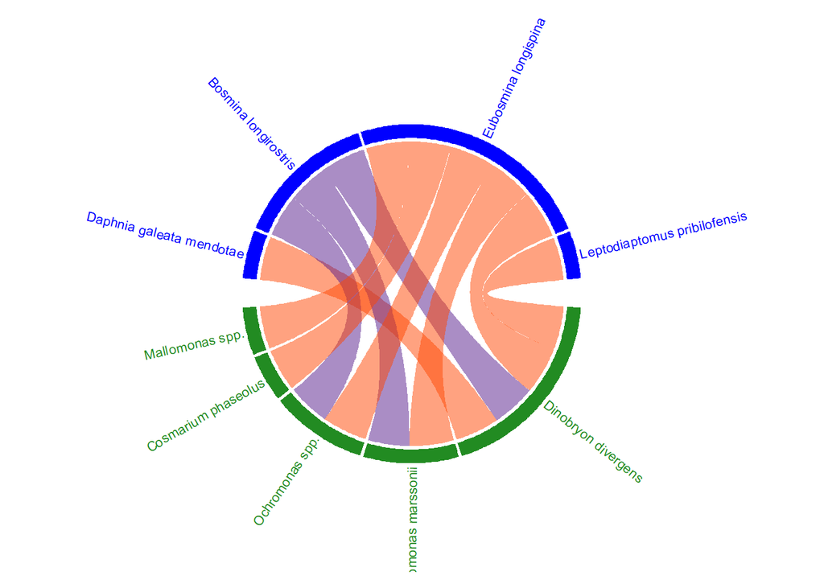

```r
circos.clear()
par(cex = 0.70, bg = "white")

circos.par(canvas.ylim = c(1.5,-1.5))

chordDiagram(toPlot.pz.long,
             grid.col = trophic.group.col,
             col = link.pz.col,
             annotationTrack = "grid")
circos.track(track.index = 1, #species names will be rotated so clearly legible
             panel.fun = function(x, y) {
               circos.text(CELL_META$xcenter, CELL_META$ylim[1] + 1.2, CELL_META$sector.index,
                           facing = "clockwise", niceFacing = TRUE, adj = c(0, 0.5), col = trophic.group.col[CELL_META$sector.index])},
             bg.border = NA)
```

and here between zooplankton and fish

[output not shown]

[output not shown]

[output not shown]

[output not shown]

[output not shown]

[output not shown]

[output not shown]

[output not shown]

[output not shown]

[output not shown]

[output not shown]

[output not shown]

[output not shown]

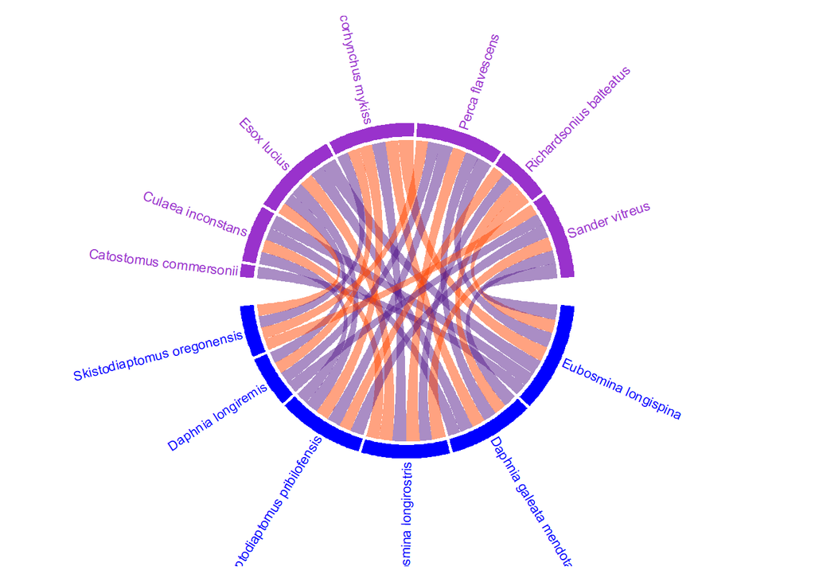

```r
circos.clear()
par(cex = 0.70, bg = "white")

circos.par(canvas.ylim = c(1.5,-1.5))

chordDiagram(toPlot.zf.long,
             grid.col = trophic.group.col,
             col = link.zf.col,
             annotationTrack = "grid")
circos.track(track.index = 1, #species names will be rotated so clearly legible
             panel.fun = function(x, y) {
               circos.text(CELL_META$xcenter, CELL_META$ylim[1] + 1.2, CELL_META$sector.index,
                           facing = "clockwise", niceFacing = TRUE, adj = c(0, 0.5), col = trophic.group.col[CELL_META$sector.index])},
             bg.border = NA)
```

## Variance Partition Figures adjusted by R2 of the model

This is the script adjusted using the R2 from the model. Ask Zofia for more info or explanation as to why this is useful. Or feel free to read our manuscript that Zofia should have a copy of where we explain our reasoning.

We pull the variation partition values into a new dataframe and multiply those values by the species corresponding R2

```r
var.par.287 <- VP.287$vals

var.par.287.adj <- var.par.287*(MF.287[["TjurR2"]])
```

I then group the environmental variables by their category

```r
var.par.287.adj.group <- matrix(ncol = ncol(var.par.287.adj), nrow = 3,
                                dimnames = list(c("Lake Morphometry", "Water Quality",
                                                  "Random: SiteID")))
colnames(var.par.287.adj.group) <- colnames(var.par.287.adj)

var.par.287.adj.group[1,] <- apply(var.par.287.adj[2:6,], 2, sum)
var.par.287.adj.group[2,] <- apply(var.par.287.adj[7:12,], 2, sum)
var.par.287.adj.group[3,] <- var.par.287.adj[13,]

var.par.287.adj.group.means <- round(rowMeans(var.par.287.adj.group), 3)*100
```

We can now plot our own custom variance partition plots

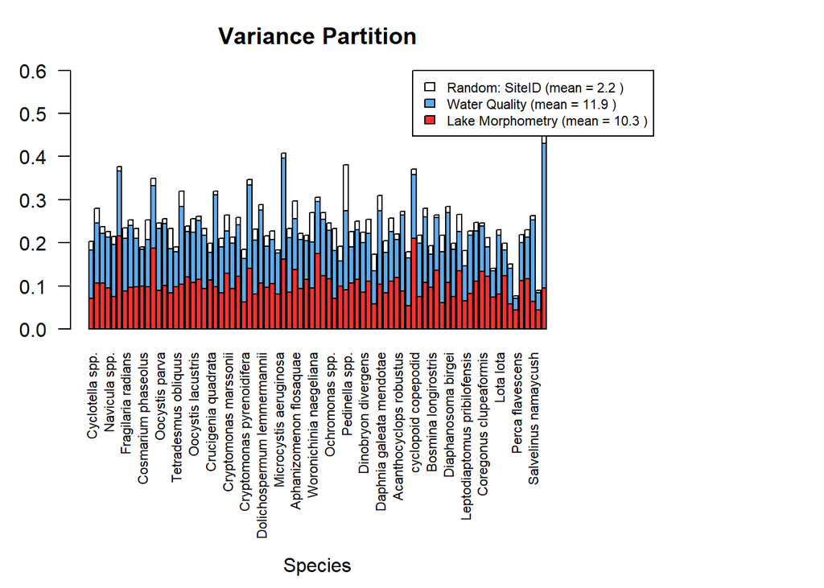

```r
par(mar=c(11,3,3,11))

barplot(var.par.287.adj.group,
        las = 2,
        cex.names = 0.7,
        main = "Variance Partition",
        legend.text = FALSE,
        ylim = c(0,0.6),
        col = c("firebrick1","steelblue2","white"))
mtext("Species", side = 1, line = 9.5)

legend("topright",
       cex = 0.7,
       legend = rev(paste(rownames(var.par.287.adj.group), paste("(mean =",
                                                                 var.par.287.adj.group.means, ")"))),
       fill = rev(c("firebrick1","steelblue2","white")),
       inset = c(-0.18,0),
       xpd = TRUE)
```

# Conclusion

We have now reached the end of the document. Hopefully my first attempt at using Rmarkdown isn’t too long winded and is more useful than tedious.

As always, if you have any questions, feel free to get in contact!

- Dario Joseph Di Girolamo